# Background

The owner of a company would like to be able to predict whether employees will stay with the company or leave.

## Data Description

The data contains information about various characteristics of employees. Please note that the dataset has been updated to account for repetitions, which is needed for Goodness of Fit Assessment. See below for the description of these characteristics.

1. **Age.Group**: 1-9 (1 corresponds to teen, 2 corresponds to twenties, etc.)
2. **Gender**: 1 if male, 0 if female
3. **Tenure**: Number of years with the company
4. **Num.Of.Products**: Number of products owned
5. **Is.Active.Member**: 1 if active member, 0 if inactive member
6. **Staying**: Fraction of employees that stayed with the company for a given set of predicting variables.

## Setup

You can import the data and set up the problem with the following R code:

```r
# Import the data
rawdata = read.csv("hw4_data.csv", header=TRUE, fileEncoding="UTF-8-BOM")

# Create variable Staying
rawdata$Staying = rawdata$Stay/rawdata$Employees

# Set variables as categoricals
rawdata$Num.Of.Products<-as.factor(rawdata$Num.Of.Products)
rawdata$Age.Group<-as.factor(rawdata$Age.Group)
rawdata$Gender<-as.factor(rawdata$Gender)
rawdata$Is.Active.Member<-as.factor(rawdata$Is.Active.Member)

# Print head of data
head(rawdata)
```

| Age.Group | Gender | Tenure | Num.Of.Products | Is.Active.Member | Stay | Employees | Staying |
| --- | --- | --- | --- | --- | --- | --- | --- |
| 2 | 1 | 3 | 1 | 0 | 5 | 11 | 0.4545455 |
| 2 | 1 | 4 | 1 | 0 | 5 | 10 | 0.5000000 |
| 2 | 1 | 4 | 1 | 1 | 2 | 13 | 0.1538462 |
| 2 | 0 | 7 | 1 | 0 | 3 | 10 | 0.3000000 |
| 2 | 1 | 7 | 1 | 0 | 2 | 14 | 0.1428571 |
| 2 | 0 | 4 | 2 | 0 | 4 | 12 | 0.3333333 |

```r
unique(rawdata$Num.Of.Products)
```

1. 1

2. 2

**Levels**:**

1. '1'

2. '2'

**Note:** For all of the following questions, treat variables **Tenure** and **Staying** as quantitative variables and **Age.Group**, **Gender**, **Num.Of.Products**, and **Is.Active.Member** as categorical variables. Categorical variables have already been converted to factors in the starter code.

# Question 1: Fitting a Model - 9 pts

Fit a logistic regression model using *Staying* as the response variable with *Num.Of.Products* as the predictor and logit as the link function. Ensure to include the weights parameter for specifying the number of trials. Call it **model1**. Note that *Num.Of.Products* should be treated as a categorical variable.

(a) 3 pts - Display the summary of model1. What are the model parameters and estimates?

```r
model1 <- glm(Staying ~ Num.Of.Products, data = rawdata, weights = Employees, family = binomial)
summary(model1)
```

```
Call:
glm(formula = Staying ~ Num.Of.Products, family = binomial, data = rawdata,
    weights = Employees)

Deviance Residuals:
    Min       1Q   Median       3Q      Max
-4.2827  -1.4676  -0.1022   1.4490   4.7231

Coefficients:
                 Estimate Std. Error z value Pr(>|z|)
(Intercept)       0.37886    0.04743   7.988 1.37e-15 ***
Num.Of.Products2 -1.76683    0.10313 -17.132  < 2e-16 ***
---
Signif. codes:  0 ‘***’ 0.001 ‘**’ 0.01 ‘*’ 0.05 ‘.’ 0.1 ‘ ’ 1

(Dispersion parameter for binomial family taken to be 1)

    Null deviance: 981.04  on 157  degrees of freedom
Residual deviance: 632.04  on 156  degrees of freedom
AIC: 1056.8

Number of Fisher Scoring iterations: 4
```

(b) 3 pts - Write down the equation for the Odds of Staying.

e^(0.37886 + -1.76683*Num.Of.Products2)

NOTE: as Num.Of.Products is a categorical variable with 2 levels, Num.Of.Products2 will be 0 if Num.Of.Products = 1, and 1 if Num.Of.Products = 2

```r
exp(-1.76683)
```

0.170873801134615

(c) 3 pts - Provide a meaningful interpretation for the estimated coefficient for *Num.Of.Products2* with respect to the log-odds of staying and the odds of staying.

# Question 2: Inference - 9 pts

(a) 3 pts - Using model1, find a 90% confidence interval for the coefficient for *Num.Of.Products2*.

```r
confint(model1, 'Num.Of.Products2', level=0.90)
#[-1.93836096298482, -1.59896517002453]
```

**5 %**

-1.93836096298482

**95 %**

-1.59896517002453

```r
# work for part b
gstat = model1$null.deviance- deviance(model1)
p_value = 1-pchisq(gstat,length(coef(model1)) -1)
cbind(gstat, p_value )
```

| gstat | p_value |
| --- | --- |
| 348.996 | 0 |

(b) 3 pts - Is model1 significant overall at the 0.01 significance level?

At a 0.01 significance level, the model is overall significant according to the output in the cell above - the P-value is approximately 0.

(c) 3 pts - Which regression coefficients are significantly nonzero at the 0.01 significance level? Which are significantly negative? Why?

Num.Of.Products2 (B1) and the intercept (B0) are significantly nonzero at the 0.01 significance level. Num.Of.Products2 is significantly negative as the z-value (-17.132) is < Pr(|z|) (2e-16).

# Question 3: Goodness of fit - 10 pts

(a) 3.5 pts - Perform goodness-of-fit hypothesis tests using both Deviance and Pearson residuals. What do you conclude? Explain the differences, if any, between these findings and what you found in Question 2b.

The p-values for both the Deviance and Pearson residuals are extremely small and approximately 0 indicating that the model is NOT a good fit. This is the opposite of what i found in question 2b using the pchisq test w/ the deviance residuals.

```r
pearres4 = residuals(model1,type="pearson")
pearson = sum(pearres4^2)
round(c(pearson, 1-pchisq(pearson,156)),2)
```

1. 562.18

2. 0

```r
round(c(deviance(model1), 1-pchisq(deviance(model1),156)),2)
```

1. 632.04

2. 0

(b) 3.5 pts - Evaluate whether the deviance residuals are normally distributed by producing a QQ plot and histogram of the deviance residuals. What assessments can you make about the goodness of fit of **model1** based on these plots?

Based on the QQ plot and the histogram below, we can see that the model has a clear skew (qq plot is curved at tails, histogram is not normally distributed) and therefore is not a good fit.

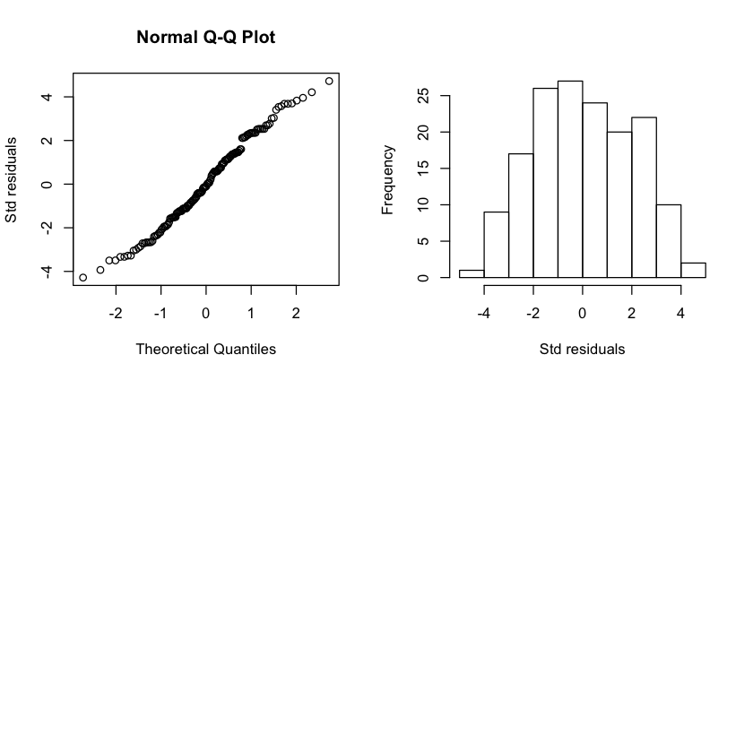

```r
res = resid(model1,type="deviance")
par(mfrow=c(2,2))
qqnorm(res, ylab="Std residuals")
hist(res,10,xlab="Std residuals", main="")
```

(c) 3 pts - Calculate the estimated dispersion parameter for this model. Is this an overdispersed model?

This model is overdispersed as the estimated overdispersion parameter (4.05) is greater than 2 (see work below).

```r
model1$deviance/model1$df.res
```

4.05153868026779

# Question 4: Fitting the full model- 23 pts

Fit a logistic regression model using *Staying* as the response variable with *Age.Group*, *Gender*, *Tenure*, *Num.Of.Products*, and *Is.Active.Member* as the predictors and logit as the link function. Ensure to include the weights parameter for specifying the number of trials. Call it **model2**. Note that Age.Group, Gender, Num.Of.Products, and Is.Active.Member should be treated as categorical variables.

```r
model2 <- glm(Staying ~ Age.Group + Gender + Tenure + Num.Of.Products + Is.Active.Member, data = rawdata,weights = Employees, family = binomial)
summary(model2)
```

```
Call:
glm(formula = Staying ~ Age.Group + Gender + Tenure + Num.Of.Products +
    Is.Active.Member, family = binomial, data = rawdata, weights = Employees)

Deviance Residuals:
     Min        1Q    Median        3Q       Max
-3.10929  -0.76949  -0.07324   0.74079   3.06551

Coefficients:
                   Estimate Std. Error z value Pr(>|z|)
(Intercept)       -0.109572   0.282617  -0.388    0.698
Age.Group3         0.384480   0.267984   1.435    0.151
Age.Group4         1.734115   0.270384   6.414 1.42e-10 ***
Age.Group5         2.955578   0.337727   8.751  < 2e-16 ***
Gender1           -0.572069   0.093776  -6.100 1.06e-09 ***
Tenure            -0.003319   0.016569  -0.200    0.841
Num.Of.Products2  -1.410946   0.112000 -12.598  < 2e-16 ***
Is.Active.Member1 -0.850280   0.095829  -8.873  < 2e-16 ***
---
Signif. codes:  0 ‘***’ 0.001 ‘**’ 0.01 ‘*’ 0.05 ‘.’ 0.1 ‘ ’ 1

(Dispersion parameter for binomial family taken to be 1)

    Null deviance: 981.04  on 157  degrees of freedom
Residual deviance: 162.35  on 150  degrees of freedom
AIC: 599.07

Number of Fisher Scoring iterations: 4
```

(a) 3 pts - Write down the equation for the probability of staying.

e^(-0.109572 + 0.384480*Age.Group3 + 1.734115*Age.Group4 + 2.955578*Age.Group5 + -0.572069*Gender1 + -0.003319*Tenure + -1.410946*Num.Of.Products2 + -0.850280*Is.Active.Member1)/(1 + e^(-0.109572 + 0.384480*Age.Group3 + 1.734115*Age.Group4 + 2.955578*Age.Group5 + -0.572069*Gender1 + -0.003319*Tenure + -1.410946*Num.Of.Products2 + -0.850280*Is.Active.Member1))

```r
# Tenure
exp(-0.003319)
```

0.996686501792001

```r
# Is.Active.Member1
exp(-0.850280)
```

0.427295272520883

(b) 3 pts - Provide a meaningful interpretation for the estimated coefficients of *Tenure* and *Is.Active.Member1* with respect to the odds of staying.

(c) 3 pts - Is *Is.Active.Member1* statistically significant given the other variables in model2 at the 0.01 significance level?

Is.Active.Member1 is statistically significant at the above confidence level as the p-value is less than 0.01.

(d) 10 pts - Has your goodness of fit been affected? Follow the instructions to repeat the tests, plots, and dispersion parameter calculation you performed in Question 3 with **model2**.

(d-1) Perform goodness-of-fit hypothesis tests using both Deviance and Pearson residuals. What do you conclude?

By looking at the GOF tests using the pearson and deviance residuals, the p-value of the pearson residual test appears to be better (higher) but the p-value of the deviance test appears to be the same (0). Therefore this model is a better fit than model 1.

```r
pearres4 = residuals(model2,type="pearson")
pearson = sum(pearres4^2)
round(c(pearson, 1-pchisq(pearson,150)),2)
```

1. 154.16

2. 0.39

```r
round(c(deviance(model2), 1-pchisq(deviance(model1),150)),2)
```

1. 162.35

2. 0

(d-2) Evaluate the linearity assumption of **model2** by plotting the log-odds of Staying vs. **Tenure**. What do you conclude?

I do not see any sign of linearity based on the plots of Staying vs Tenure. Therefore this assumption fails.

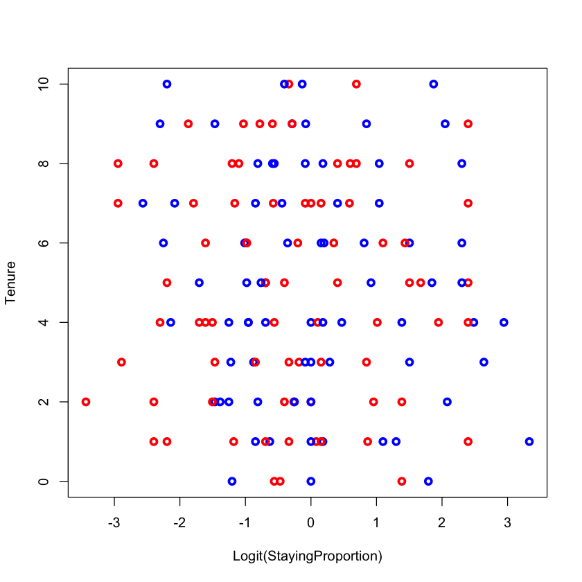

```r
plot(log(rawdata$Staying/(1-rawdata$Staying)), rawdata$Tenure, col=c("red","blue"),
     xlab="Logit(StayingProportion)",ylab="Tenure", lwd=3)
```

(d-3) Evaluate whether the deviance residuals are normally distributed by producing a QQ plot and histogram of the deviance residuals. What do you conclude?

The deviance residuals appear to be less skewed than model 1 according to the QQ plot and have a distribution which looks more normal according to the histogram. Therefore the GOF appears to be better than model 1.

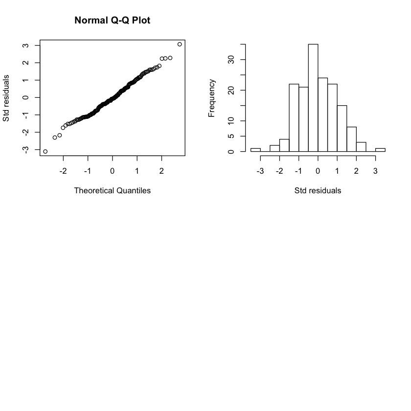

```r
res = resid(model2,type="deviance")
par(mfrow=c(2,2))
qqnorm(res, ylab="Std residuals")
hist(res,10,xlab="Std residuals", main="")
```

(d-4) Calculate the estimated dispersion parameter for this model. Is this an overdispersed model?

This model is not overdispersed as the estimated overdispersion parameter (1.08) is less than 2 (see work below).

```r
model2$deviance/model2$df.res
```

1.08232994001588

(e) 4 pts - Overall, would you say model2 is a good-fitting model? If so, why? If not, what would you suggest to improve the fit and why? Note: We are not asking you to spend hours finding the best possible model but to offer plausible suggestions along with your reasoning.

# Question 5: Prediction - 9 pts

Suppose there is an employee with the following characteristics:

1. **Age.Group**: 2
2. **Gender**: 0
3. **Tenure**: 2
4. **Num.Of.Products**: 2
5. **Is.Active.Member**: 1

(a) 3 pts - Predict their probability of staying using model1.

```r
Age.Group <- as.factor(2)
Gender <- as.factor(0)
Tenure <-  c(2)
Num.Of.Products <-  as.factor(2)
Is.Active.Member <-  as.factor(1)
new  = data.frame(Age.Group, Gender, Tenure, Num.Of.Products, Is.Active.Member)
```

```r
predict(model1, new, type = 'response')
```

**1:** 0.199731903560706

(b) 3 pts - Predict their probability of staying using model2.

```r
predict(model2, new, type = 'response')
```

**1:** 0.0849095806679074

(c) 3 pts - Comment on how your predictions compare. i.e. which model is more reliable based on the analysis?

The probability of staying is higher for an employee with the respective characteristics when model 1 is used vs model 2. Based on my analysis and especially looking at the goodness of fit tests, I would say that model 2 is more reliable. Model 2 is also not overdispersed, unlike model 1.